# ggplot tutorial

2017/3/6

## About me

- Economist.
- Data Analyst, KKBOX Data science team.
- Amuture pâtissier and home chef.

## What is data science?

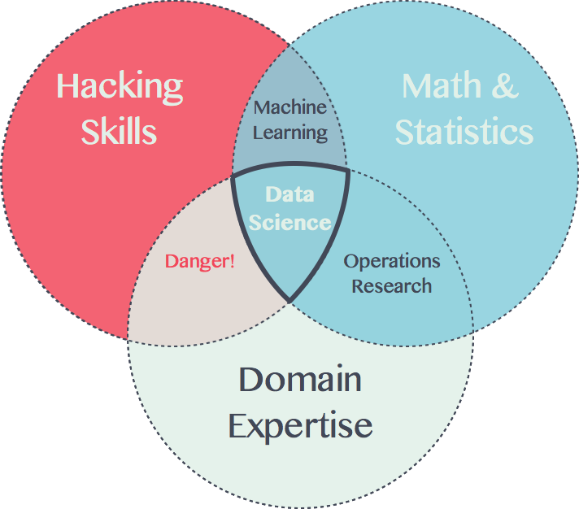

## What does data scientist do? (Reversed)

- 運用資料視覺化工具呈現研究結果
  - ggplot!
- 詮釋或利用適當的統計方法分析資料
- 取得、清洗、轉化資料
  - "If you torture the data enough, nature will always confess."(Ronald Coase, 1981)
  - [it can even be a mutual torturing activity](https://www.r-bloggers.com/a-glimpse-into-the-daily-life-of-a-data-scientist/)

## What does data scientist do? (Reversed)

- 瞭解你的資料
  - 裡面有些什麼?
  - 資料欄位代表些什麼?
  - 資料的分佈、變數間的關聯
  - 裡頭有沒有錯?
  - 也是ggplot 的用處!

## What does data scientist do? (Reversed)

- 定義問題. (但通常是「重新定義」問題)
  - 「這首歌會紅嗎？」 (X)
  - 「什麼數據或指標可以有效的預測歌曲熱門度？」 (O)
- 最重要的兩個階段，但常常都需要先探索資料才會出現好的問題
- Difference between mediocre/tedious and intriguing/great data science project

## 一圖值千金

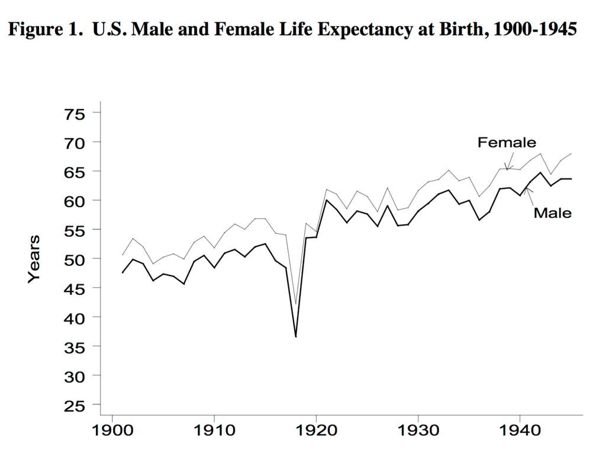

[1918 flu pandemic](http://www.birdflubook.org/resources/brainerd1.pdf)

## 環境

```r
library(tidyverse)
```

## 讀入資料

- [臺北市政府警察局交通警察大隊/交通事故資料](http://data.taipei/opendata/datalist/datasetMeta?oid=2f238b4f-1b27-4085-93e9-d684ef0e2735)
- 使用**readr**的**read_csv**函數，而不是內建的**read.csv**

```r
traffic <- read_csv("traffic_eng.csv")
head(traffic, n=3)
```

```
## # A tibble: 3 × 19
##   time.year time.month time.day time.hour time.minute event.level
##       <int>      <int>    <int>     <int>       <int>       <chr>
## 1       104          1        1         0          18        一般
## 2       104          1        1         0          18        一般
## 3       104          1        1         0          18        一般
## # ... with 13 more variables: location.district <chr>,
## #   location.address <chr>, number.dead <int>, number.injury <int>,
## #   party.sn <int>, vehicle.type <chr>, party.gender <chr>,
## #   party.age <int>, party.injury <chr>, location.weather <chr>,
## #   location.speed.limit <int>, location.road.type <chr>,
## #   location.type <chr>
```

## 探索資料

- 看一下時間分佈好了

```r
traffic %>%
    select(time.month, time.day, time.hour, time.minute) %>%
    summary()
```

```
##    time.month       time.day       time.hour      time.minute
##  Min.   : 1.00   Min.   : 1.00   Min.   : 0.00   Min.   : 0.0
##  1st Qu.: 4.00   1st Qu.: 8.00   1st Qu.: 9.00   1st Qu.:13.0
##  Median : 7.00   Median :16.00   Median :14.00   Median :30.0
##  Mean   : 6.79   Mean   :15.67   Mean   :13.65   Mean   :27.6
##  3rd Qu.:10.00   3rd Qu.:23.00   3rd Qu.:18.00   3rd Qu.:42.0
##  Max.   :12.00   Max.   :31.00   Max.   :23.00   Max.   :59.0
```

- 看的出來是24小時制的紀錄方式，但如果想知道整體分配，這樣好像沒什麼感覺

## 探索資料

- 每小時的分配次數?

```r
traffic %>%
    group_by(time.hour) %>%
    count() -> pivot.time.hour
pivot.time.hour %>% head(5)
```

```
## # A tibble: 5 × 2
##   time.hour     n
##       <int> <int>
## 1         0   849
## 2         1   513
## 3         2   360
## 4         3   282
## 5         4   298
```

- 5個值的話還好，24個呢? 60? 365?

## 探索資料, your first ggplot

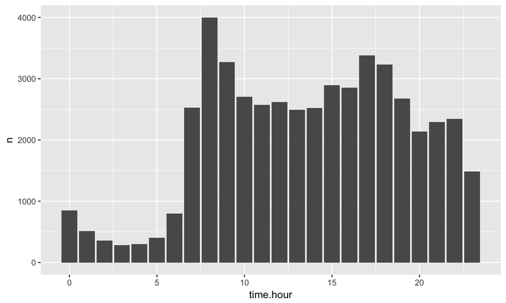

```r
qq <- ggplot(data = pivot.time.hour)
qq <- qq + geom_bar(aes(x=time.hour, y=n), stat = "identity")
print(qq)
```

## 探索資料, your first ggplot

```r
qq <- ggplot(data = pivot.time.hour)
qq <- qq + geom_bar(aes(x=time.hour, y=n), stat = "identity")
print(qq)
```

- 發生了什麼事？
- 準備好畫紙**ggplot()**，指定要畫的資料是**pivot.time.hour**
- 疊加上一層長條圖**geom_bar()**，**aes()**指定x軸與y軸。
- 資料已經計算好個數，**stat = "identity"**指定使用的數據是已算好的結果
- **print()**把圖表印出來!

## ggplot and Grammar of Graphics

- ggplot遵循一套稱為"Grammar of Graphics"的設計準則，將圖表拆解成許多元素
- 疊圖!
- **aes()**代表了"Aesthetic mapping"，指定那些看的見的元素
- 位置(x, y)、顏色(color, fill)、形狀(shape)、大小(size)……
- **geom_**系列的函數，決定"Geometric object"，這些元素最後組成什麼圖表
- 長條圖(bar)、散點圖(point)、折線圖(line)……etc.

## ggplot and Grammar of Graphics

- 圖表的類型可以輕易的被改變，利用折線圖**geom_line()**取代長條圖**geom_bar()**

```r
qq <- ggplot(data = pivot.time.hour)
qq <- qq + geom_line(aes(x=time.hour, y=n))
print(qq)
```

## ggplot and Grammar of Graphics

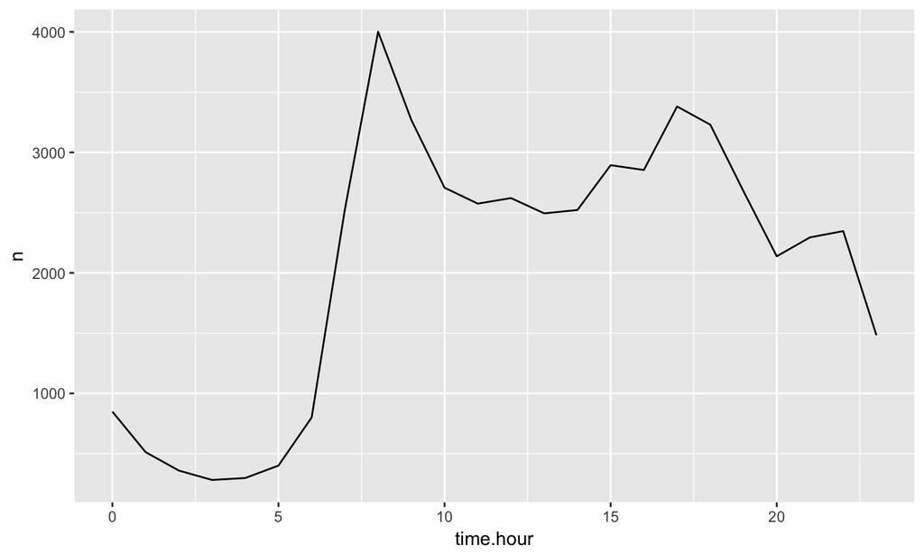

## ggplot and Grammar of Graphics

- 甚至疊加!

```r
qq <- ggplot(data = pivot.time.hour)
qq <- qq + geom_line(aes(x=time.hour, y=n))
qq <- qq + geom_point(aes(x=time.hour, y=n))
print(qq)
```

## ggplot and Grammar of Graphics

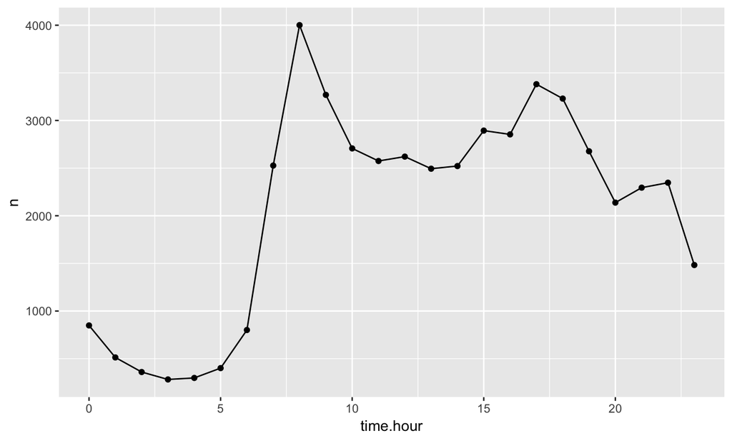

## 探索資料, more!

- 來戰南北囉啊不對這是台北市的資料
- 那就戰男女!!! 把剛才的時序資料，按照性別分開

```r
traffic %>%
    group_by(time.hour, party.gender) %>%
    count() -> pivot.hour.gender

pivot.hour.gender %>% head(3)
```

```
## Source: local data frame [3 x 3]
## Groups: time.hour [1]
##
##   time.hour         party.gender     n
##       <int>                <chr> <int>
## 1         0                   男   629
## 2         0                   女   195
## 3         0 無或物(動物、堆置物)    25
```

## 探索資料, 戰男女!

```r
qq <- ggplot(data = pivot.hour.gender)
qq <- qq + geom_line(aes(x=time.hour, y=n, colour=party.gender))
print(qq)
```

- **aes()**中依舊包含關於位置的資訊(x, y)，但是這次有新朋友**colour=party.gender**
- 本來都是一樣的黑色，那顏色本身能不能包含資訊呢?
- **colour=party.gender**代表「利用性別這個欄位，著上不同的顏色！」
- colour, size, shape……等等，都可以用這種方式呈現！

## 探索資料, 戰男女!

- 需要外星翻譯官…….

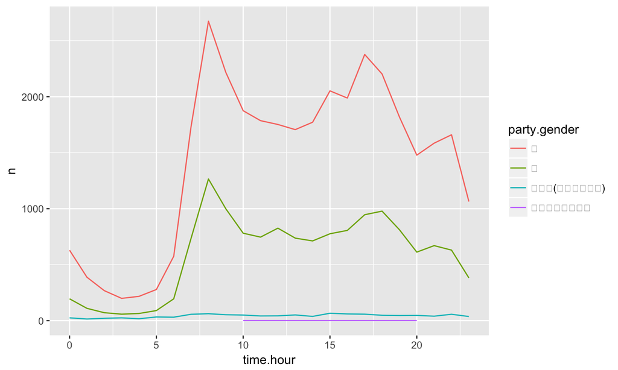

## More than data

- R是洋人的玩意ㄦ，ggplot也是……八月丨五殺韃了!!!!
- 預設字型，顯示不了中文!
- 需要指定可以兼容的字型，交給**theme()**來處理這些資料以外的問題!

## More than data

```r
qq <- ggplot(data = pivot.hour.gender)
qq <- qq + geom_line(aes(x=time.hour, y=n, colour=party.gender))
qq <- qq + theme(text=element_text(family = "Microsoft JhengHei",
                                   colour="red"))
print(qq)
```

## More than data

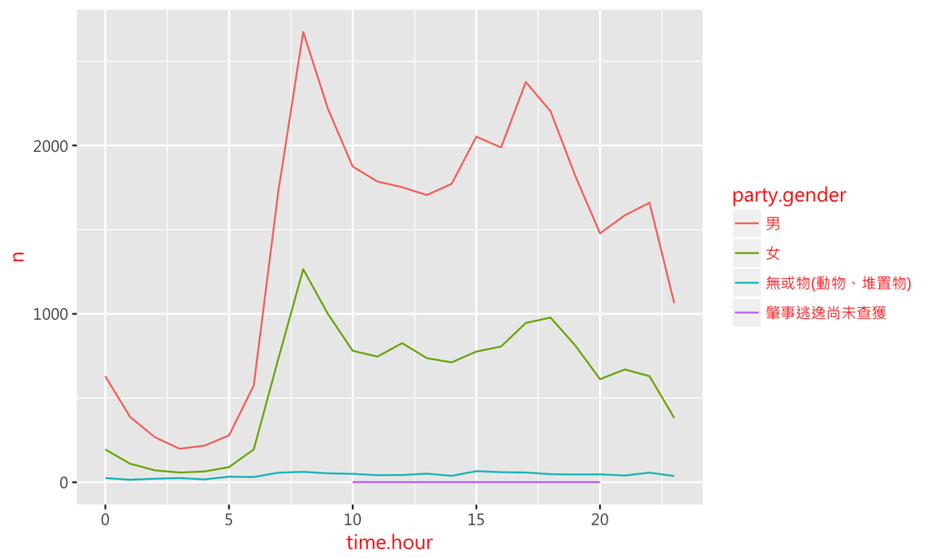

- 圖上的字型，現在都變成微軟正黑體的形狀啦!

## Improve it!

- 把這張圖交出去的話會被電沒被電的話你要懷疑你上司的程度
- 沒有圖表標題
- x軸與y軸是什麼意思?
- x軸想要每3個小時畫一個標記，y軸的字能不能轉向?
- 圖例補上標題，放在底下

## Improve it!

```r
qq <- ggplot(data = pivot.hour.gender)
qq <- qq + geom_line(aes(x=time.hour, y=n, colour=party.gender))
qq <- qq + theme(text=element_text(family = "Microsoft JhengHei"),
                 axis.title.y = element_text(angle = 0, vjust = 0.5),
                 legend.position = "bottom")
qq <- qq + labs(title="台北市每時交通事故人數，按性別分",
                x="時間", y="人數")
qq <- qq + scale_x_continuous(breaks = seq(0,24,3))
qq <- qq + scale_colour_discrete(name="當事人性別")
print(qq)
```

- **theme()**裡新增了對y軸標題的修改，包括字串呈現的角度(angle)與位置(vjust)，並將圖例(legend)的位置放到底部
- **labs()**指定x軸與y軸的變數說明，以及整張圖的大標題(title)
- **scale_x_continuous()**每3個小時產生一個斷點(breaks)
- **scale_colour_discrete()**修改圖例的名稱

## Improve it!

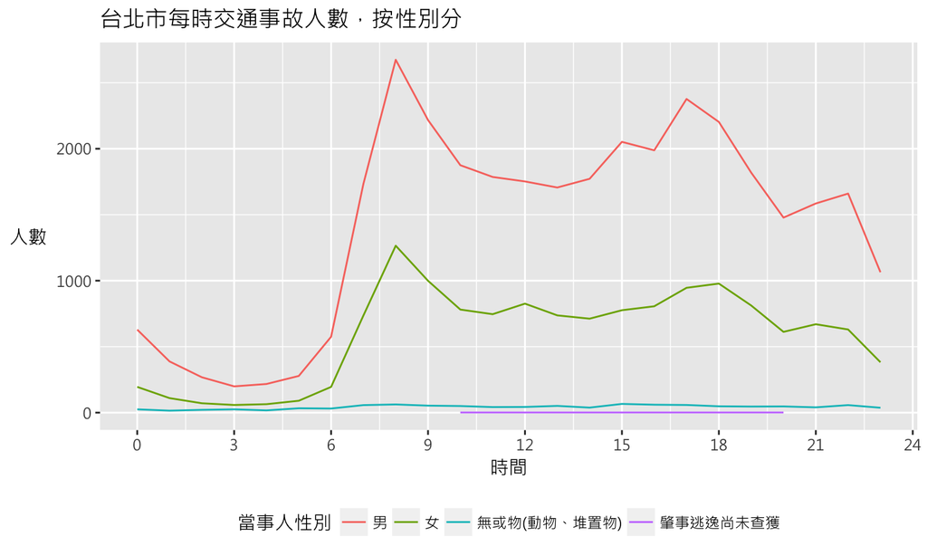

## It's show time!

- 試試看利用簡單的敘述統計跟ggplot，探索一下這筆資料吧!
- 畫個「分鐘」的長條圖，你會發現警察登記時的習性
- 除了這個資料，我們準備了一些有趣的東西可以玩
- 20年的大學榜單資料
- moss要想辦法生出來的資料

## 你的名字

```r
college.admission <- read_csv("college_admission.csv")
college.admission %>% arrange(-n) %>% head(5)
```

```
## # A tibble: 5 × 6
##    year first.name first.pinyin        n national.colleges top.5.colleges
##   <int>      <chr>        <chr>    <dbl>             <dbl>          <dbl>
## 1  1999       怡君        yijun 407.0708         126.86109       44.61049
## 2  2000       怡君        yijun 398.6149         112.73957       36.23772
## 3  2001       怡君        yijun 379.4943         109.54474       28.69029
## 4  2002       雅婷       yating 379.2310         113.12653       28.28163
## 5  2003       雅婷       yating 352.9057          90.54816       19.73486
```

## 菜市場來的

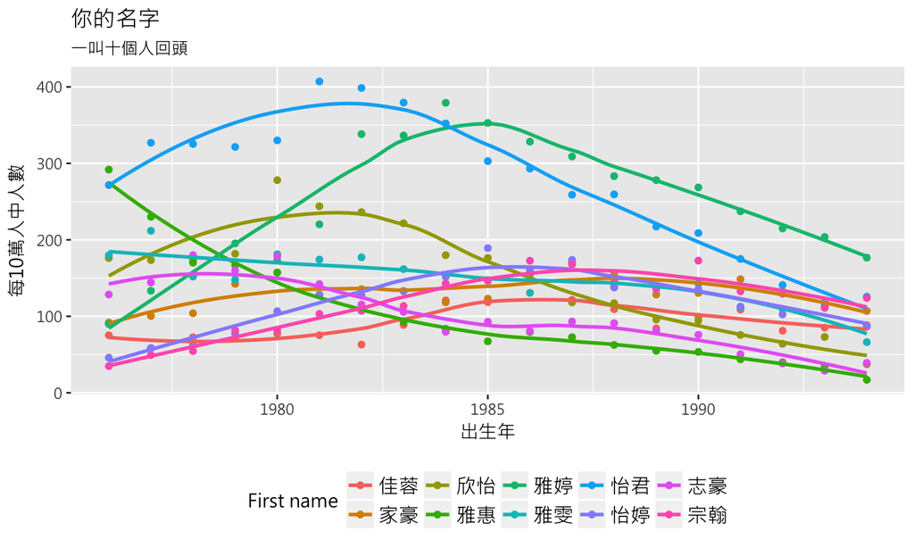

## 聽起來就像學妹

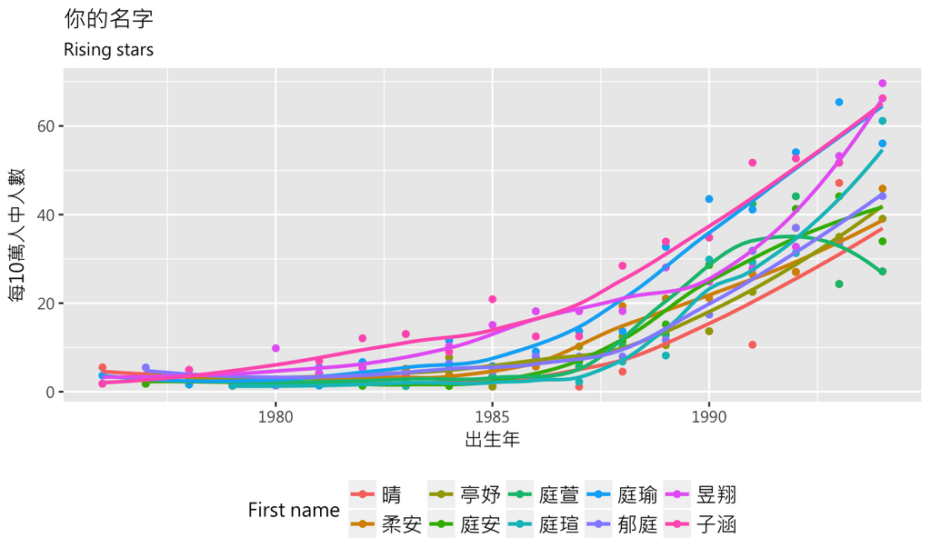

## 好像轉到民視

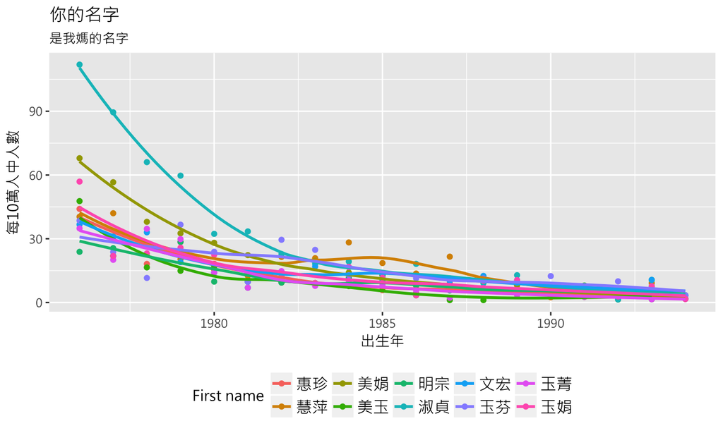

## Let's try it!

[figure not shown]